# Working with data in Python for Beginners

[figure not shown]

# Introduction

My Name is **Jean-Pierre Voogt**, but you can call me **JP**.

```
Twitter : JP.Voogt
Email   : jvoogt1@gmail.com
```

I am a Data Analyst (Aspiring Data Scientist) for a Credit Bureau in South Africa.

[figure not shown]

## Jupyter Notebooks

### What is a Notebook

Jupyter Notebook is an open-source web application that allows you to create and share documents that contain live code, equations, visualizations and narrative text.

Source: https://jupyter.org/

[figure not shown]

### Tips and Tricks

Source : https://www.dataquest.io/blog/jupyter-notebook-tips-tricks-shortcuts/

```
new cell below: command context + b
delete cell: command context + dd
all commands Ctrl + Shift + P
```

## LETS GET STARTED

**Import all our required libaries**

```python
%matplotlib inline

import numpy as np
import pandas as pd
import matplotlib.pyplot as plt
import seaborn as sns
sns.set()

pd.options.mode.chained_assignment = None
```

```
Numpy: https://numpy.org/
Pandas: https://pandas.pydata.org/
PyPlot: https://matplotlib.org/users/pyplot_tutorial.html
```

**PANDAS DATAFRAMES**

class pandas.DataFrame(data=None, index=None, columns=None, dtype=None, copy=False)[source]

Two-dimensional size-mutable, potentially heterogeneous tabular data structure with labeled axes (rows and columns). Arithmetic operations align on both row and column labels. Can be thought of as a dict-like container for Series objects. The primary pandas data structure.

```
https://pandas.pydata.org/pandas-docs/stable/reference/api/pandas.DataFrame.html
```

### Manual Data

Quick example of how to load random data into a Pandas dataframe

```python
dates = pd.date_range('20190101', periods=6, freq="D" )
df = pd.DataFrame(np.random.randn(6, 4), index=dates, columns=list('ABCD'))
df
```

|  | A | B | C | D |
| --- | --- | --- | --- | --- |
| 2019-01-01 | 0.601101 | -0.011405 | 0.159401 | -0.485579 |
| 2019-01-02 | 0.910877 | 0.159360 | 0.334049 | 0.346296 |
| 2019-01-03 | 1.530438 | 2.671749 | -0.034264 | 0.333619 |
| 2019-01-04 | -0.018869 | -0.029191 | -1.034522 | -0.510830 |
| 2019-01-05 | 0.762909 | -0.763466 | -0.480625 | -1.053513 |
| 2019-01-06 | 0.304143 | 0.088737 | -0.476739 | 0.892585 |

```
date_range: https://pandas.pydata.org/pandas-docs/stable/reference/api/pandas.date_range.html
DataFrame: https://pandas.pydata.org/pandas-docs/stable/reference/api/pandas.DataFrame.html
Randn: https://docs.scipy.org/doc/numpy-1.13.0/reference/generated/numpy.random.randn.html
```

### Look for CSV files in our working Dir

Below we query the OS in our working Directory to see what .csv files we have to work with

```python
import os
items = os.listdir("Data\.")

newlist = []
for names in items:
    if names.endswith(".csv"):
        newlist.append(names)
print(newlist)
```

```
['PGA_Data_Historical.csv']
```

Source: **Kaggle**

**Unix Command** ls to also view the Directory structure

```python
%ls
```

### Read CSV into Dataframe

```python
dataframe = pd.read_csv("data\PGA_Data_Historical.csv")#, sep = ',', decimal='.')
```

**Display**: Different ways to display the data in a notebook

```python
print(dataframe.head(3))
```

```
       Player Name  Season         Statistic                     Variable  \
0  Robert Garrigus    2010  Driving Distance  Driving Distance - (ROUNDS)
1     Bubba Watson    2010  Driving Distance  Driving Distance - (ROUNDS)
2   Dustin Johnson    2010  Driving Distance  Driving Distance - (ROUNDS)

  Value
0    71
1    77
2    83
```

```python
dataframe.head(3)
```

|  | Player Name | Season | Statistic | Variable | Value |
| --- | --- | --- | --- | --- | --- |
| 0 | Robert Garrigus | 2010 | Driving Distance | Driving Distance - (ROUNDS) | 71 |
| 1 | Bubba Watson | 2010 | Driving Distance | Driving Distance - (ROUNDS) | 77 |
| 2 | Dustin Johnson | 2010 | Driving Distance | Driving Distance - (ROUNDS) | 83 |

## Viewing our data

**Data shape rows and columns**

```python
print(dataframe.shape)
```

```
(2740403, 5)
```

**View first x records**

head() and tail() originated from the Unix commands

```python
dataframe.head(2)
```

|  | Player Name | Season | Statistic | Variable | Value |
| --- | --- | --- | --- | --- | --- |
| 0 | Robert Garrigus | 2010 | Driving Distance | Driving Distance - (ROUNDS) | 71 |
| 1 | Bubba Watson | 2010 | Driving Distance | Driving Distance - (ROUNDS) | 77 |

**Display last 3 records**

```python
dataframe.tail(3)
```

|  | Player Name | Season | Statistic | Variable | Value |
| --- | --- | --- | --- | --- | --- |
| 2740400 | Andrew Yun | 2018 | Fairway Bunker Tendency | Fairway Bunker Tendency - (RELATIVE TO PAR) | +0.225 |
| 2740401 | Nate Lashley | 2018 | Fairway Bunker Tendency | Fairway Bunker Tendency - (RELATIVE TO PAR) | +0.143 |
| 2740402 | Martin Flores | 2018 | Fairway Bunker Tendency | Fairway Bunker Tendency - (RELATIVE TO PAR) | +0.181 |

**Display only selected columns**

```python
# This will return a Series Object
dataframe["Player Name"].head(5)
```

```
0    Robert Garrigus
1       Bubba Watson
2     Dustin Johnson
3    Brett Wetterich
4        J.B. Holmes
Name: Player Name, dtype: object
```

```python
# This will return a Dataframe Object
dataframe[["Player Name","Season"]].head()
```

|  | Player Name | Season |
| --- | --- | --- |
| 0 | Robert Garrigus | 2010 |
| 1 | Bubba Watson | 2010 |
| 2 | Dustin Johnson | 2010 |
| 3 | Brett Wetterich | 2010 |
| 4 | J.B. Holmes | 2010 |

```python
# This will return a Series Object
dataframe.Season.head(2)
```

```
0    2010
1    2010
Name: Season, dtype: int64
```

### META DATA

```python
dataframe.dtypes
```

```
Player Name    object
Season          int64
Statistic      object
Variable       object
Value          object
dtype: object
```

```python
dataframe.index
```

```
RangeIndex(start=0, stop=2740403, step=1)
```

```python
dataframe.columns
```

```
Index(['Player Name', 'Season', 'Statistic', 'Variable', 'Value'], dtype='object')
```

```python
dataframe.values
```

### Data Investigations and Transitions

Lets take a look at what columns we have to work with in our dataset

```python
dataframe.describe()
```

```python
dataframe.T
```

|  | 0 | 1 | 2 | 3 | 4 | 5 | 6 | 7 | 8 | 9 | ... | 2740393 | 2740394 | 2740395 | 2740396 | 2740397 | 2740398 | 2740399 | 2740400 | 2740401 | 2740402 |
| --- | --- | --- | --- | --- | --- | --- | --- | --- | --- | --- | --- | --- | --- | --- | --- | --- | --- | --- | --- | --- | --- |
| Player Name | Robert Garrigus | Bubba Watson | Dustin Johnson | Brett Wetterich | J.B. Holmes | John Daly | Graham DeLaet | Angel Cabrera | Charles Warren | D.J. Trahan | ... | Michael Kim | Peter Malnati | Jason Day | Rory Sabbatini | Mackenzie Hughes | Ben Martin | Robert Streb | Andrew Yun | Nate Lashley | Martin Flores |
| Season | 2010 | 2010 | 2010 | 2010 | 2010 | 2010 | 2010 | 2010 | 2010 | 2010 | ... | 2018 | 2018 | 2018 | 2018 | 2018 | 2018 | 2018 | 2018 | 2018 | 2018 |
| Statistic | Driving Distance | Driving Distance | Driving Distance | Driving Distance | Driving Distance | Driving Distance | Driving Distance | Driving Distance | Driving Distance | Driving Distance | ... | Fairway Bunker Tendency | Fairway Bunker Tendency | Fairway Bunker Tendency | Fairway Bunker Tendency | Fairway Bunker Tendency | Fairway Bunker Tendency | Fairway Bunker Tendency | Fairway Bunker Tendency | Fairway Bunker Tendency | Fairway Bunker Tendency |
| Variable | Driving Distance - (ROUNDS) | Driving Distance - (ROUNDS) | Driving Distance - (ROUNDS) | Driving Distance - (ROUNDS) | Driving Distance - (ROUNDS) | Driving Distance - (ROUNDS) | Driving Distance - (ROUNDS) | Driving Distance - (ROUNDS) | Driving Distance - (ROUNDS) | Driving Distance - (ROUNDS) | ... | Fairway Bunker Tendency - (RELATIVE TO PAR) | Fairway Bunker Tendency - (RELATIVE TO PAR) | Fairway Bunker Tendency - (RELATIVE TO PAR) | Fairway Bunker Tendency - (RELATIVE TO PAR) | Fairway Bunker Tendency - (RELATIVE TO PAR) | Fairway Bunker Tendency - (RELATIVE TO PAR) | Fairway Bunker Tendency - (RELATIVE TO PAR) | Fairway Bunker Tendency - (RELATIVE TO PAR) | Fairway Bunker Tendency - (RELATIVE TO PAR) | Fairway Bunker Tendency - (RELATIVE TO PAR) |
| Value | 71 | 77 | 83 | 54 | 100 | 63 | 88 | 64 | 64 | 92 | ... | +0.155 | +0.155 | +0.161 | +0.188 | +0.188 | +0.209 | +0.239 | +0.225 | +0.143 | +0.181 |

5 rows × 2740403 columns

### DDL Modifications

Changing the schema layout of your Dataframe

```python
dataframe.rename(columns = {'Value':'Distance'}).head(3)
```

|  | Player Name | Season | Statistic | Variable | Distance |
| --- | --- | --- | --- | --- | --- |
| 0 | Robert Garrigus | 2010 | Driving Distance | Driving Distance - (ROUNDS) | 71 |
| 1 | Bubba Watson | 2010 | Driving Distance | Driving Distance - (ROUNDS) | 77 |
| 2 | Dustin Johnson | 2010 | Driving Distance | Driving Distance - (ROUNDS) | 83 |

```python
dataframe.head(3)
```

|  | Player Name | Season | Statistic | Variable | Value |
| --- | --- | --- | --- | --- | --- |
| 0 | Robert Garrigus | 2010 | Driving Distance | Driving Distance - (ROUNDS) | 71 |
| 1 | Bubba Watson | 2010 | Driving Distance | Driving Distance - (ROUNDS) | 77 |
| 2 | Dustin Johnson | 2010 | Driving Distance | Driving Distance - (ROUNDS) | 83 |

```python
dataframe.rename(columns = {'Value':'Distance'}, inplace=True)
```

```python
dataframe = dataframe.rename(columns = {'Value':'Distance'})
```

### Altering Data Types

```
https://stackoverflow.com/questions/15891038/change-data-type-of-columns-in-pandas
```

```python
Distance = dataframe.query('Variable=="Driving Distance - (AVG.)"')
Distance.dtypes
```

```
Player Name    object
Season          int64
Statistic      object
Variable       object
Distance       object
dtype: object
```

```python
Distance.head(3)
```

|  | Player Name | Season | Statistic | Variable | Distance |
| --- | --- | --- | --- | --- | --- |
| 192 | Robert Garrigus | 2010 | Driving Distance | Driving Distance - (AVG.) | 315.5 |
| 193 | Bubba Watson | 2010 | Driving Distance | Driving Distance - (AVG.) | 309.8 |
| 194 | Dustin Johnson | 2010 | Driving Distance | Driving Distance - (AVG.) | 308.5 |

```python
Distance[["Distance"]] = Distance[["Distance"]].apply(pd.to_numeric)
Distance.dtypes
```

```
Player Name     object
Season           int64
Statistic       object
Variable        object
Distance       float64
dtype: object
```

### Rename a column

**Remeber to set inplace=True**

```python
column_names = {"Player Name":"PlayerName","Season":"Season_YY","Statistic":"Statistic","Variable":"Variable","Distance":"Distance"}

Distance.rename(columns=column_names, inplace=True)
Distance.head()
```

|  | PlayerName | Season_YY | Statistic | Variable | Distance |
| --- | --- | --- | --- | --- | --- |
| 192 | Robert Garrigus | 2010 | Driving Distance | Driving Distance - (AVG.) | 315.5 |
| 193 | Bubba Watson | 2010 | Driving Distance | Driving Distance - (AVG.) | 309.8 |
| 194 | Dustin Johnson | 2010 | Driving Distance | Driving Distance - (AVG.) | 308.5 |
| 195 | Brett Wetterich | 2010 | Driving Distance | Driving Distance - (AVG.) | 307.3 |
| 196 | J.B. Holmes | 2010 | Driving Distance | Driving Distance - (AVG.) | 307.2 |

**Drop a column**

```python
Distance.drop("Statistic", axis = 1, inplace=True)
Distance.head()
```

|  | PlayerName | Season_YY | Variable | Distance |
| --- | --- | --- | --- | --- |
| 192 | Robert Garrigus | 2010 | Driving Distance - (AVG.) | 315.5 |
| 193 | Bubba Watson | 2010 | Driving Distance - (AVG.) | 309.8 |
| 194 | Dustin Johnson | 2010 | Driving Distance - (AVG.) | 308.5 |
| 195 | Brett Wetterich | 2010 | Driving Distance - (AVG.) | 307.3 |
| 196 | J.B. Holmes | 2010 | Driving Distance - (AVG.) | 307.2 |

## Sorting Data

**sort by index**

```python
dataframe.sort_index(axis=1, ascending=False).head(5)
```

**Sort by column name**

```python
dataframe.sort_values(by='Player Name').head()
```

|  | Player Name | Season | Statistic | Variable | Distance |
| --- | --- | --- | --- | --- | --- |
| 2605938 | A.J. McInerney | 2018 | Consecutive Par 3 Birdies | Consecutive Par 3 Birdies - (NUMBER OF HOLES) | 1 |
| 2675982 | A.J. McInerney | 2018 | FedExCup Season Points for Non-Members | FedExCup Season Points for Non-Members - (WGC ... | NaN |
| 2511827 | A.J. McInerney | 2018 | Consecutive Fairways Hit | Consecutive Fairways Hit - (CURRENT STREAK) | NaN |
| 2522325 | A.J. McInerney | 2018 | First Tee Late Lowest Round | First Tee Late Lowest Round - (ROUNDS) | 12 |
| 2470013 | A.J. McInerney | 2018 | Total Money (Official and Unofficial) | Total Money (Official and Unofficial) - (EVENTS) | 4 |

## Data Slicing

```python
dataframe.Season.unique()
```

```
array([2010, 2011, 2012, 2013, 2014, 2015, 2016, 2017, 2018], dtype=int64)
```

```python
#dataframe[["Season"]].unique()
dataframe["Season"].unique()
```

```
array([2010, 2011, 2012, 2013, 2014, 2015, 2016, 2017, 2018], dtype=int64)
```

```python
dataframe[6:8]
```

|  | Player Name | Season | Statistic | Variable | Distance |
| --- | --- | --- | --- | --- | --- |
| 6 | Graham DeLaet | 2010 | Driving Distance | Driving Distance - (ROUNDS) | 88 |
| 7 | Angel Cabrera | 2010 | Driving Distance | Driving Distance - (ROUNDS) | 64 |

```python
dataframe[-4:-1]
```

|  | Player Name | Season | Statistic | Variable | Distance |
| --- | --- | --- | --- | --- | --- |
| 2740399 | Robert Streb | 2018 | Fairway Bunker Tendency | Fairway Bunker Tendency - (RELATIVE TO PAR) | +0.239 |
| 2740400 | Andrew Yun | 2018 | Fairway Bunker Tendency | Fairway Bunker Tendency - (RELATIVE TO PAR) | +0.225 |
| 2740401 | Nate Lashley | 2018 | Fairway Bunker Tendency | Fairway Bunker Tendency - (RELATIVE TO PAR) | +0.143 |

### loc vs iloc

```
loc gets rows (or columns) with particular labels from the index.
iloc gets rows (or columns) at particular positions in the index (so it only takes integers)
```

```python
dataframe.loc[:,["Season","Player Name"]].head()
```

|  | Season | Player Name |
| --- | --- | --- |
| 0 | 2010 | Robert Garrigus |
| 1 | 2010 | Bubba Watson |
| 2 | 2010 | Dustin Johnson |
| 3 | 2010 | Brett Wetterich |
| 4 | 2010 | J.B. Holmes |

```python
dataframe.loc[9,["Season","Player Name"]]
```

```
Season                2010
Player Name    D.J. Trahan
Name: 9, dtype: object
```

#### iloc

```
.iloc[from row : to row, from column : to column]
```

```python
dataframe.iloc[:,1:].head()
```

|  | Season | Statistic | Variable | Distance |
| --- | --- | --- | --- | --- |
| 0 | 2010 | Driving Distance | Driving Distance - (ROUNDS) | 71 |
| 1 | 2010 | Driving Distance | Driving Distance - (ROUNDS) | 77 |
| 2 | 2010 | Driving Distance | Driving Distance - (ROUNDS) | 83 |
| 3 | 2010 | Driving Distance | Driving Distance - (ROUNDS) | 54 |
| 4 | 2010 | Driving Distance | Driving Distance - (ROUNDS) | 100 |

## Filter Data

```python
dataframe["Player Name"].head() == "Ernie Els"
```

```
0    False
1    False
2    False
3    False
4    False
Name: Player Name, dtype: bool
```

```python
df_ernie = dataframe[dataframe["Player Name"] == "Ernie Els"]
df_ernie.head()
```

|  | Player Name | Season | Statistic | Variable | Distance |
| --- | --- | --- | --- | --- | --- |
| 89 | Ernie Els | 2010 | Driving Distance | Driving Distance - (ROUNDS) | 72 |
| 281 | Ernie Els | 2010 | Driving Distance | Driving Distance - (AVG.) | 288.4 |
| 473 | Ernie Els | 2010 | Driving Distance | Driving Distance - (TOTAL DISTANCE) | 40,374 |
| 665 | Ernie Els | 2010 | Driving Distance | Driving Distance - (TOTAL DRIVES) | 140 |
| 914 | Ernie Els | 2010 | Driving Accuracy Percentage | Driving Accuracy Percentage - (ROUNDS) | 72 |

### Query Data

**isin Function**

```python
dataframe[dataframe["Variable"].isin(["Driving Distance - (AVG.)","Driving Distance - (TOTAL DRIVES)"])].head()
```

|  | Player Name | Season | Statistic | Variable | Distance |
| --- | --- | --- | --- | --- | --- |
| 192 | Robert Garrigus | 2010 | Driving Distance | Driving Distance - (AVG.) | 315.5 |
| 193 | Bubba Watson | 2010 | Driving Distance | Driving Distance - (AVG.) | 309.8 |
| 194 | Dustin Johnson | 2010 | Driving Distance | Driving Distance - (AVG.) | 308.5 |
| 195 | Brett Wetterich | 2010 | Driving Distance | Driving Distance - (AVG.) | 307.3 |
| 196 | J.B. Holmes | 2010 | Driving Distance | Driving Distance - (AVG.) | 307.2 |

```python
players = pd.DataFrame(dataframe[dataframe["Season"].isin(["2010","2011"])])
players["Player Name"].head().unique().tolist()
```

```
['Robert Garrigus',
 'Bubba Watson',
 'Dustin Johnson',
 'Brett Wetterich',
 'J.B. Holmes']
```

**.query Function**

Simular to the Where Clause in T-SQL

```python
players = dataframe.query('Variable=="Driving Distance - (AVG.)"').query('Distance > "315"')
players["Player Name"].unique().tolist()
```

```
['Robert Garrigus',
 'J.B. Holmes',
 'Bubba Watson',
 'Dustin Johnson',
 'Rory McIlroy',
 'Trey Mullinax',
 'Tom Lovelady',
 'Tony Finau']
```

```python
players = dataframe.query('Variable=="Driving Distance - (AVG.)" and Distance > "315"')
players["Player Name"].unique().tolist()
```

```
['Robert Garrigus',
 'J.B. Holmes',
 'Bubba Watson',
 'Dustin Johnson',
 'Rory McIlroy',
 'Trey Mullinax',
 'Tom Lovelady',
 'Tony Finau']
```

## Altering/Manipulating Data

**Changing Data**

```python
players.loc[192,:]
```

```
Player Name              Robert Garrigus
Season                              2010
Statistic               Driving Distance
Variable       Driving Distance - (AVG.)
Distance                           315.5
Name: 192, dtype: object
```

```python
players.loc[192,["Distance"]] = 215.8
```

```python
players.loc[192,:]
```

```
Player Name              Robert Garrigus
Season                              2010
Statistic               Driving Distance
Variable       Driving Distance - (AVG.)
Distance                           215.8
Name: 192, dtype: object
```

### Adding a new column

```python
from random import randint

players["Draw"] = randint(0, 18)
players.head()
```

|  | Player Name | Season | Statistic | Variable | Distance | Draw |
| --- | --- | --- | --- | --- | --- | --- |
| 192 | Robert Garrigus | 2010 | Driving Distance | Driving Distance - (AVG.) | 215.8 | 16 |
| 323269 | J.B. Holmes | 2011 | Driving Distance | Driving Distance - (AVG.) | 318.4 | 16 |
| 628386 | Bubba Watson | 2012 | Driving Distance | Driving Distance - (AVG.) | 315.5 | 16 |
| 1524473 | Dustin Johnson | 2015 | Driving Distance | Driving Distance - (AVG.) | 317.7 | 16 |
| 1524474 | Bubba Watson | 2015 | Driving Distance | Driving Distance - (AVG.) | 315.2 | 16 |

## Aggregations

```python
players.groupby(["Player Name"])["Distance"].max()
```

```
Player Name
Bubba Watson       315.5
Dustin Johnson     317.7
J.B. Holmes        318.4
Robert Garrigus    215.8
Rory McIlroy       319.7
Tom Lovelady       315.9
Tony Finau         315.1
Trey Mullinax      318.3
Name: Distance, dtype: object
```

## Pivot Tables

**Filter dataset down to only the needed data**

```python
dataframe["Statistic"].head().unique().tolist()
```

[output not shown]

```python
dataframe[dataframe["Statistic"] == "Driving Distance"].Variable.unique().tolist()
```

```
['Driving Distance - (ROUNDS)',
 'Driving Distance - (AVG.)',
 'Driving Distance - (TOTAL DISTANCE)',
 'Driving Distance - (TOTAL DRIVES)']
```

## Create filtered Dataframe

```python
driving_dist = dataframe[dataframe["Statistic"] == "Driving Distance"]
driving_dist.head()
```

|  | Player Name | Season | Statistic | Variable | Distance |
| --- | --- | --- | --- | --- | --- |
| 0 | Robert Garrigus | 2010 | Driving Distance | Driving Distance - (ROUNDS) | 71 |
| 1 | Bubba Watson | 2010 | Driving Distance | Driving Distance - (ROUNDS) | 77 |
| 2 | Dustin Johnson | 2010 | Driving Distance | Driving Distance - (ROUNDS) | 83 |
| 3 | Brett Wetterich | 2010 | Driving Distance | Driving Distance - (ROUNDS) | 54 |
| 4 | J.B. Holmes | 2010 | Driving Distance | Driving Distance - (ROUNDS) | 100 |

**Drop columns that nolonger add value**

```python
driving_dist.drop(["Statistic"], axis = 1, inplace=True)
```

## Rename Columns

```python
column_names = {"Player Name":"PlayerName","Season":"Season_YY","Variable":"Variable","Distance":"Distance"}
driving_dist.rename(columns=column_names, inplace=True)
```

## Fix data type for Distance

```python
driving_dist.dtypes
```

```
PlayerName    object
Season_YY      int64
Variable      object
Distance      object
dtype: object
```

```python
driving_dist.loc[384,:]
```

```
PlayerName                        Robert Garrigus
Season_YY                                    2010
Variable      Driving Distance - (TOTAL DISTANCE)
Distance                                   41,009
Name: 384, dtype: object
```

## Fix data type for Distance

```python
driving_dist['Distance'] = [x.replace(',', '.') for x in driving_dist['Distance']]
driving_dist[driving_dist["Variable"]=="Driving Distance - (TOTAL DISTANCE)"].head()
```

|  | PlayerName | Season_YY | Variable | Distance |
| --- | --- | --- | --- | --- |
| 384 | Robert Garrigus | 2010 | Driving Distance - (TOTAL DISTANCE) | 41.009 |
| 385 | Bubba Watson | 2010 | Driving Distance - (TOTAL DISTANCE) | 47.703 |
| 386 | Dustin Johnson | 2010 | Driving Distance - (TOTAL DISTANCE) | 50.588 |
| 387 | Brett Wetterich | 2010 | Driving Distance - (TOTAL DISTANCE) | 33.187 |
| 388 | J.B. Holmes | 2010 | Driving Distance - (TOTAL DISTANCE) | 61.437 |

```python
driving_dist[["Distance"]] = driving_dist[["Distance"]].apply(pd.to_numeric)
driving_dist.dtypes
```

```
PlayerName     object
Season_YY       int64
Variable       object
Distance      float64
dtype: object
```

## Build Single Index Pivot Table

Create new dataframe with only data for 2018 Driving Distances

```python
driving_dist_2018 = driving_dist[driving_dist["Season_YY"] == 2018]
```

Drop Columns that we no longer need

```python
driving_dist_2018.drop(["Season_YY"], axis = 1, inplace=True)
```

## Create the Pivot

```python
driving_dist_2018.pivot(index="PlayerName", columns="Variable",values="Distance").head(10)
```

| Variable PlayerName | Driving Distance - (AVG.) | Driving Distance - (ROUNDS) | Driving Distance - (TOTAL DISTANCE) | Driving Distance - (TOTAL DRIVES) |
| --- | --- | --- | --- | --- |
| Aaron Baddeley | 295.3 | 84.0 | 46.068 | 156.0 |
| Aaron Wise | 302.9 | 90.0 | 53.314 | 176.0 |
| Abraham Ancer | 296.1 | 98.0 | 56.850 | 192.0 |
| Adam Hadwin | 289.4 | 92.0 | 44.574 | 154.0 |
| Adam Schenk | 305.5 | 86.0 | 48.881 | 160.0 |
| Adam Scott | 304.6 | 78.0 | 42.649 | 140.0 |
| Alex Cejka | 286.7 | 77.0 | 39.567 | 138.0 |
| Alex Noren | 299.2 | 67.0 | 33.506 | 112.0 |
| Andrew Landry | 291.1 | 82.0 | 46.569 | 160.0 |
| Andrew Putnam | 293.8 | 97.0 | 52.295 | 178.0 |

## Multi Index Pivot

```python
driving_dist_pvt = driving_dist.set_index(["PlayerName","Season_YY"]).pivot(columns="Variable")['Distance'].reset_index().rename_axis(None, axis=1)
driving_dist_pvt.head(10)
```

|  | PlayerName | Season_YY | Driving Distance - (AVG.) | Driving Distance - (ROUNDS) | Driving Distance - (TOTAL DISTANCE) | Driving Distance - (TOTAL DRIVES) |
| --- | --- | --- | --- | --- | --- | --- |
| 0 | Aaron Baddeley | 2010 | 298.9 | 94.0 | 56.202 | 188.0 |
| 1 | Aaron Baddeley | 2011 | 296.2 | 77.0 | 44.430 | 150.0 |
| 2 | Aaron Baddeley | 2012 | 292.0 | 73.0 | 42.048 | 144.0 |
| 3 | Aaron Baddeley | 2013 | 288.5 | 68.0 | 38.086 | 132.0 |
| 4 | Aaron Baddeley | 2014 | 293.8 | 74.0 | 39.950 | 136.0 |
| 5 | Aaron Baddeley | 2015 | 294.1 | 76.0 | 42.941 | 146.0 |
| 6 | Aaron Baddeley | 2016 | 291.7 | 93.0 | 51.925 | 178.0 |
| 7 | Aaron Baddeley | 2017 | 292.6 | 61.0 | 31.014 | 106.0 |
| 8 | Aaron Baddeley | 2018 | 295.3 | 84.0 | 46.068 | 156.0 |
| 9 | Aaron Watkins | 2013 | 277.1 | 46.0 | 24.388 | 88.0 |

## Pretty Graphs

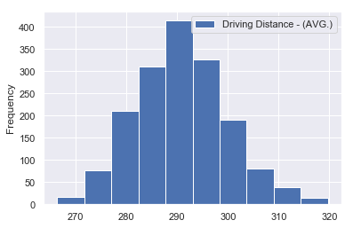

```python
driving_dist_pvt[["Driving Distance - (AVG.)"]].plot(kind = "hist")
```

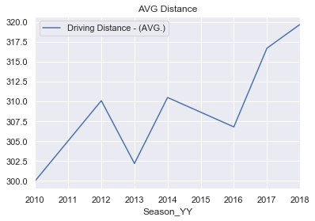

```python
Rory = driving_dist_pvt[driving_dist_pvt["PlayerName"] == "Rory McIlroy"]
ax = Rory[["Driving Distance - (AVG.)","Season_YY"]].plot(kind = "line",title = "AVG Distance", x= "Season_YY")
ax
```

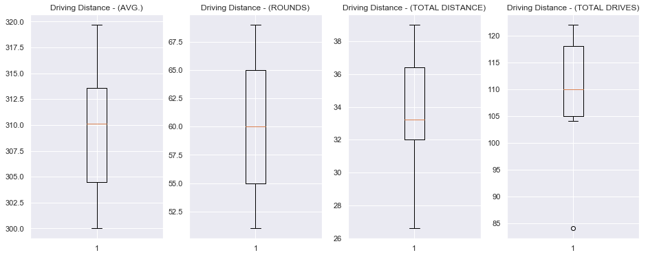

|  | Driving Distance - (AVG.) | Driving Distance - (ROUNDS) | Driving Distance - (TOTAL DISTANCE) | Driving Distance - (TOTAL DRIVES) |
| --- | --- | --- | --- | --- |
| count | 7.000000 | 7.000000 | 7.000000 | 7.000000 |
| mean | 309.428571 | 60.000000 | 33.679286 | 108.857143 |
| std | 7.165127 | 6.658328 | 4.120675 | 12.902565 |
| min | 300.000000 | 51.000000 | 26.600000 | 84.000000 |
| 25% | 304.500000 | 55.000000 | 32.034500 | 105.000000 |
| 50% | 310.100000 | 60.000000 | 33.240000 | 110.000000 |
| 75% | 313.600000 | 65.000000 | 36.423000 | 118.000000 |
| max | 319.700000 | 69.000000 | 39.000000 | 122.000000 |

```python
plt.figure(1, figsize=(20,6))
for i in range(2,6):
    plt.subplot(1,5,i)
    plt.boxplot(Rory[Rory.columns[i]])
    plt.title(Rory.columns[i])
plt.show()
Rory.iloc[:,2:].describe()
```

## Iterate Dataframe

Try to avoid doing this as Pandas have functions for almost any data manipulation use case

```python
for x in range(5):
    print(x)
```

```
0
1
2
3
4
```

```python
for idx, row in players.iterrows():
    print(idx, row.Distance)
```

```
192 215.8
323269 318.4
628386 315.5
1524473 317.7
1524474 315.2
2127385 316.7
2433411 319.7
2433412 318.3
2433413 315.9
2433414 315.1
```

## Export Dataframe

**To CSV**

```python
players.to_csv("players.csv")
```

[figure not shown]

**To SQL SERVER/Database)**

```python
import sqlalchemy as sa
import pyodbc

engine = sa.create_engine("mssql+pyodbc://SOMESERVER/MYDATABASE?driver=SQL+Server+Native+Client+11.0")
dataFrame.to_sql("players", con=engine)
```

[figure not shown]

[figure not shown]